# Module 12: Summing up and some cautionary notes

TMA4268 Statistical Learning V2023

Stefanie Muff, Department of Mathematical Sciences, NTNU

May 04, 2023

# Overview

$~$

- Course content and learning outcome
- Overview of modules and core course topics
- Some cautionary notes

Some of the figures and slides in this presentation are taken (or are inspired) from G. James et al. (2021) .

# Learning outcomes of TMA4268

1. **Knowledge.** The student has knowledge about the most popular statistical learning models and methods that are used for *prediction* and *inference* in science and technology. Emphasis is on regression- and classification-type statistical models.
2. **Skills.** The student can, based on an existing data set, *choose a suitable statistical model, apply sound statistical methods*, and *perform the analyses using statistical software*. The student can present, interpret and communicate the results from the statistical analyses, and knows which conclusions can be drawn from the analyses, and what are the caveats.

$~$

**And**: you got to be an expert in using the R language and writing R Markdown reports.

# The exam

$~$

- **School exam** June 1st, 15-19h.

$~$

Tentative plan:

- Warm up section.
- 1-2 examples with real data.
- A conceptual/theoretical section testing your understanding.
- A section with single/multiple choice questions.

$~$

**Check out the exam from 2022 and additional information on the course website:**

https://wiki.math.ntnu.no/tma4268/2023v/subpage16

# The course book

$~$

Attention:

- We have now worked with the *second edition* this year: https://www.statlearning.com/
- This edition included a new chapter on Deep Learning, which we discussed in module 11.

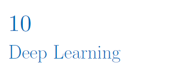

# Core of the course

Supervised and unsupervised learning:

- : regression and classification
  - examples of regression and classification type problems
  - how complex a model to get the best fit?  
    $\rightarrow$ flexiblity/overfitting/underfitting.
  - the bias-variance trade-off
  - how to find a good fit - validation and cross-validation (or AIC-type solutions)
  - how to compare different solutions
  - how to evaluate the fit - on new unseen data
- : how to find structure or groupings in data?

and of course all **the methods** (with underlying models) to perform regression, classification and unsupervised learning.

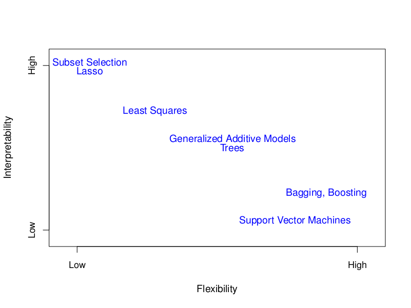

Figure 2.7 from Gareth James et al. (2013)

# The modules

## 1. Introduction

$~$

- Examples, the modules, required background in statistics
- Introduction to R and RStudio via the online R-course

## 2. Statistical learning

$~$

- Model complexity
  - Prediction vs. interpretation (inference).
  - Parametric vs. nonparametric.
  - Flexible vs. inflexible.
  - Overfitting vs. underfitting
- Supervised vs. unsupervised.
- Regression and classification.
- Loss functions: quadratic and 0/1 loss.
- Bias-variance trade-off (polynomial example): mean squared error, training and test set.
- Vectors and matrices, rules for mean and covariances, the multivariate normal distribution.

## 3. Linear regression

$~$

- The classical normal linear regression model on vector/matrix form.
- Parameter estimators and distribution thereof. Model fit.
- Confidence intervals, hypothesis tests, and interpreting R-output from regression.
- Qualitative covariates, interactions.
- This module is a stepping stone for all subsequent uses of regression in Modules 6, 7, 8, and 11.

## 4. Classification (Mainly two-class problems)

$~$

- Bayes classifier: classify to the most probable class to minimize the expected 0/1 loss. We usually do not know the probability of each class for each input. The Bayes optimal boundary is the boundary for the Bayes classifier and the error rate (on a test set) for the Bayes classifier is the Bayes error rate.

$~$

- Two paradigms (not in textbook):
  - (directly estimating the posterior distribution for the classes). Example: KNN classifier, logistic regression.
  - (estimating class prior probabilities and class conditional distribution and then putting together with Bayes rule). Examples: LDA, QDA with linear or quadratic class boundaries.

$~$

- ROC curves, AUC, sensitivity and specificity of classification methods.

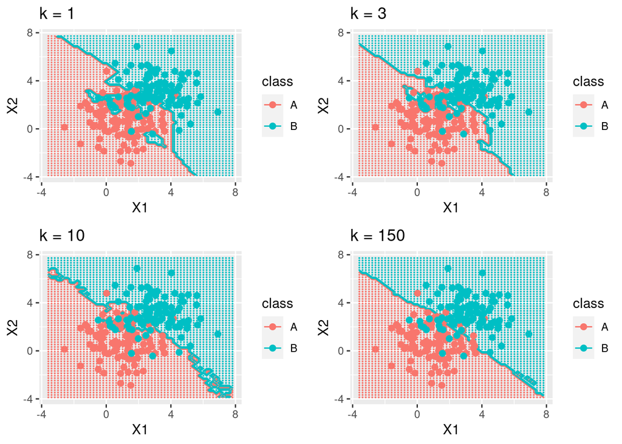

Logistic regression gives a probability, given a certain value of the covariats $P(Y=1 \, | \, \boldsymbol{x})$.

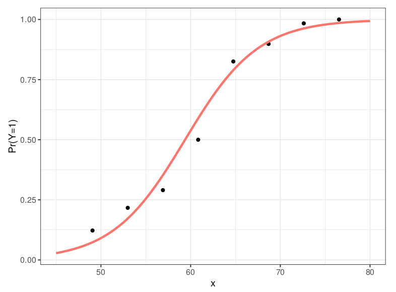

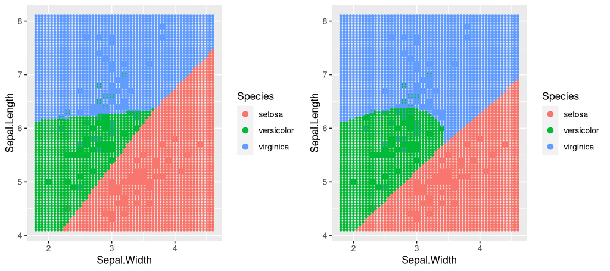

## 5. Resampling methods

$~$

**Cross-validation**

- Data rich situation: Training, validation and test set.
- Validation set approach.
- Cross-validation for regression and for classification.
- LOOCV, 5 and 10 fold CV.
- Good and bad issues with validation set, LOOCV, 10-fold CV.
- Bias and variance for $k$-fold cross-validation.
- Selection bias – the right and wrong way to do cross-validation.
- Distinction between model selection and model assessment.

$~$

**The Bootstrap**

- Idea: Re-use the same data to estimate a statistic of interest by *sampling with replacement*.

## 6. Linear model selection and regularization:

$~$

Subset-selection. Discriminate:

- : estimate performance of different models to choose the best one.
- : having chosen a final model, estimate its performance on new data.

$~$

How?

- Model selection by
  - Subset selection (best subset selection or stepwise model selection)
  - Penalizing the training error: AIC, BIC, $C_p$, Adjusted $R^2$.
  - Cross-validation.
- Model assessment by
  - Cross-validation.

### Model selection

$~$

- Shrinkage methods
  - ridge regression: quadratic L2 penalty added to RSS
  - lasso regression: absolute L1 penalty added to RSS
  - no penalty on intercept, not scale invariant: center and scale covariates

  $~$
- Dimension reduction methods:
  - principal component analysis: eigenvectors, proportion of variance explained, scree plot
  - principal component regression
  - partial least squares

  $~$
- High dimensionality issues: multicollinearity, interpretation.

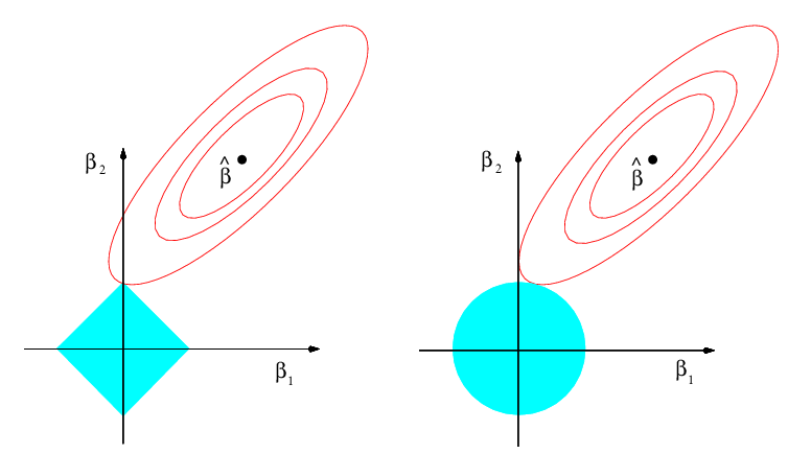

ISL 6.7

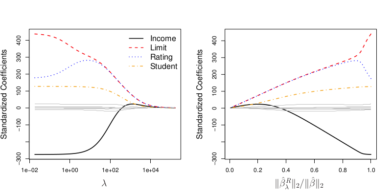

ISL 6.4

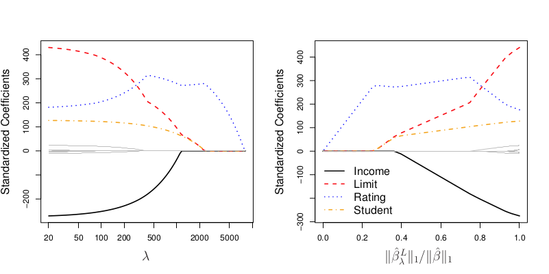

ISL 6.6

## 7. Moving beyond linearity

$~$

- Modifications to the multiple linear regression model - when a linear model is not the best choice. First look at one covariate, combine in “additive model”.
- Basis functions: fixed functions of the covariates.
- Polynomial regression: multiple linear regression with polynomial components as basis functions.
- Step functions - piecewise constants. Like our dummy variable coding of factors.
- Regression splines: regional polynomials joined smoothly - neat use of basis functions. Cubic splines very popular.
- Smoothing splines: smooth functions - minimizing the RSS with an additional penalty on the second derivative of the curve. Results in a natural cubic spline with knots in the unique values of the covariate.
- Local regressions: smoothed $K$-nearest neighbour with local regression and weighting. In applied areas `loess` is very popular.
- (Generalized) additive models (GAMs): combine the above. Sum of (possibly) non-linear instead of linear functions.

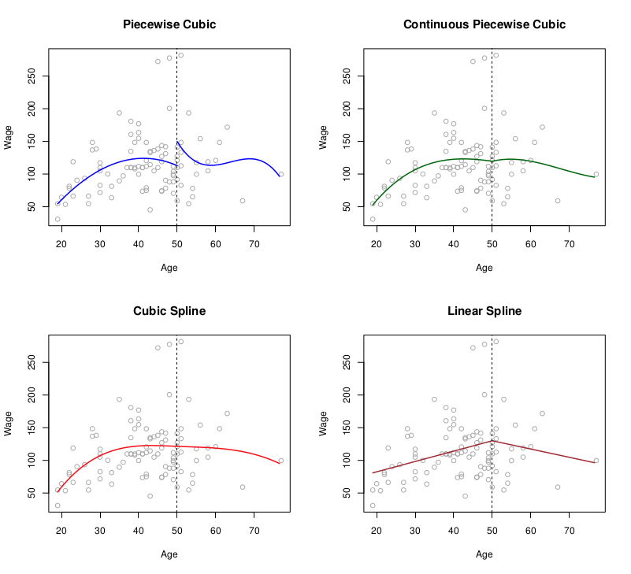

ISL 7.3

## 8. Tree-based methods

$~$

- Method applicable both to regression and classification ($K$ classes) and will give non-linear covariate effects and include interactions between covariates.
- A tree can also be seen as a division of the covariate space into non-overlapping regions.
- Binary splits using only at the current best split: *greedy strategy*.
- Minimization criterion: residual sums of squares (RSS), Gini index or cross-entropy.
- Stopping criterion: When to stop: decided stopping criterion - like minimal decrease in RSS or less than 10 observations in terminal node.
- Prediction:
  - Regression: Mean in box $R_j$
  - Classification: Majority vote or cut-off on probabiity.
- *Pruning*: Grow full tree, and then prune back using pruning strategy: cost complexity pruning.

To improve prediction (but worse interpretation):

- *Bagging* (bootstrap aggregation): draw $B$ bootstrap samples and fit one full tree to each, used the average over all trees for prediction.
- *Random forest*: as bagging but only $m$ (randomly) chosen covariates (out of the $p$) are available for selection at each possible split.
- Out-of-bag estimation can be used for model selection - no need for cross-validation.
- Variable importance plots.
- *Boosting*: fit one tree with $d$ splits, make residuals and fit a new tree, adjust residuals partly with new tree - repeat.

## 9. Support vector machines

$~$

- SVM can be used both classification and regression, but we have only studied two-class classification.
- Aim: find high dimensional hyperplane that separates two classes $f({\bf x})=\beta_0+{\bf x}^T \boldsymbol\beta=0$. If $y_if({\bf x}_i)>0$ observation ${\bf x}_i$ is correctly classified.
- Maximizing the distance (on both sides) from the class boundary to the closes observations (the margin $M$).
- Relaxed with slack variables (support vector classifiers), and to allow nonlinear functions of ${\bf x}$ (inner products).
- Support vectors: observations that lie on the margin or on the wrong side of the margin.

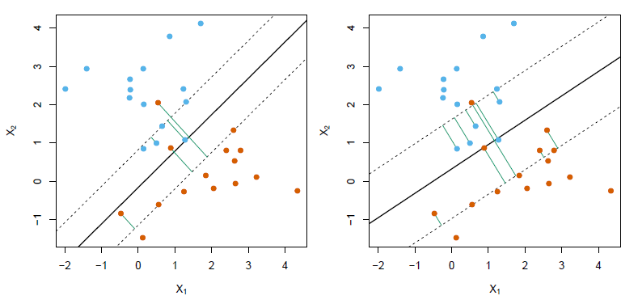

casi Figure 19.3

- Kernels: generalization of an inner product to allow for non-linear boundaries
- Most popular kernel is radial
  $$K(x_i,x_i')=\exp(-\gamma\sum_{j=1}^p
  (x_{ij}-x_{i'j})^2) \ .$$
- Tuning parameters: cost and parameters in kernels - chosen by CV.
- Unfortunately not able to present details since then a course in optimization is needed.

## 10. Unsupervised learning

$~$

- Principal component analysis:
  - Mathematical details (eigenvectors corresponding to covariance or correlation matrix) also in TMA4267.
  - Understanding loadings, scores and the biplot, choosing the number of principal components from proportion of variance explained or scree-type plots (elbow).
- Clustering:
  - $k$-means: number of clusters given, iterative algorithm to classify to nearest centroid and recalculate centroid
  - Hierarchical clustering: choice of distance measure, choice of linkage method (single, average, complete),

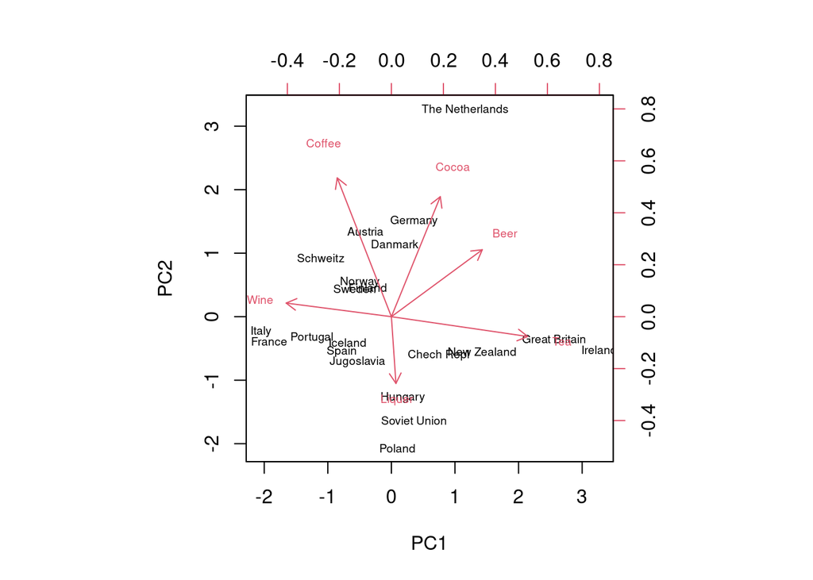

Hierarchical clustering for visualization

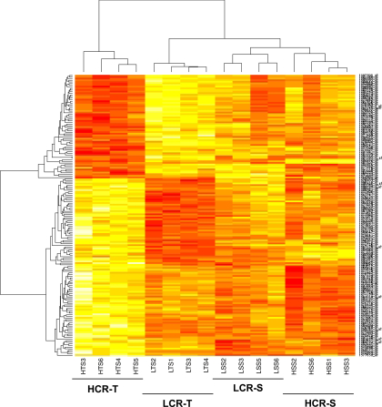

## 11. Neural networks

$~$

- Feedforward network architecture: mathematical formula - layers of multivariate transformed (`relu`, `linear`, `sigmoid`) inner products - sequentially connected.

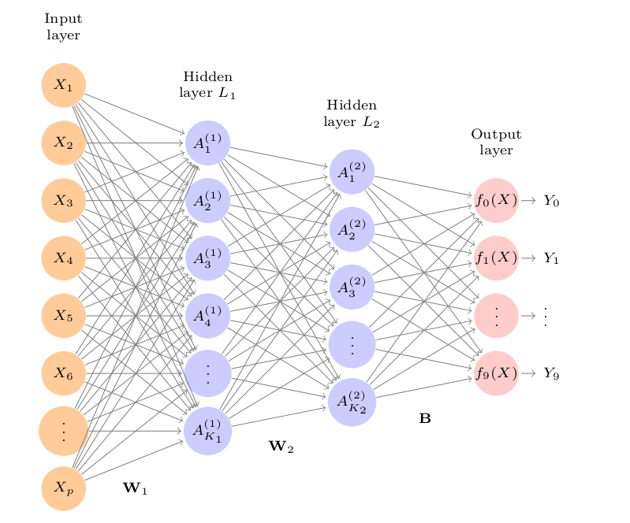

- Loss function to minimize (on output layer): regression (mean squared), classification binary (binary crossentropy), classification multiple classes (categorical crossentropy).
- Remember the correct choice of output activiation function: mean squared loss goes with linear activation, binary crossentropy with sigmoid, categorical crossentropy with softmax.
- Gradient based (chain rule) back-propagation.
- Over-fitting $\rightarrow$ Regularization.
- Convolutional neural networks (CNNs), recursive neural networks (RNNs) and transformers (Daesoo’s lecture).
- `keras` in R. Use of tensors: Piping sequential layers, piping to estimation and then to evaluation (metrics).

# Mentimeter poll

$~$

www.menti.com

Code 16 18 55 1

# Some cautionary words

$~$

- In most of the problems we looked at we could (or had to) choose a set of variables to explain or predict an outcome ($y$).
- Model selection was the topic of Module 6, but there is more to say about it, in particular in the regression context.
- Importantly, the approach to find a model **heavily depends on the aim** for which the model is built.

$~$

It is important to make the following distinction:

- The aim is to future values of $y$ from known regressors.
- The aim is to $y$ using known regressors. In this case, the ultimate aim is to find *causal relationships*.

$\rightarrow$ Even among statisticians there is no real consensus about how, if, or when to select a model:

[figure not shown]

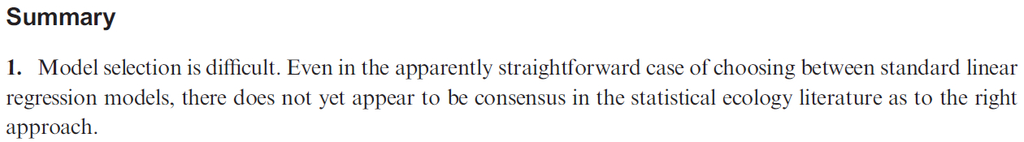

Note: The first sentence of a paper in *Methods in Ecology and Evolution* from 2016 is: ``Model selection is difficult.’’

## Why is finding a model so hard?

$~$

A model is an approximation of the reality. The aim of statistics and data analysis is to find connections (explanations or predictions) thanks to simplifications of the real world.

$~$

Box (1979):

$~$ $~$

$\rightarrow$ There is often not a “right” or a “wrong” model – but there are more and less useful ones.

$~$

$\rightarrow$ Finding a model or the appropriate method with good properties is sometimes an art…

## Predictive and explanatory models

$~$

When choosing a method or a model, you need to be clear about the scope:

$~$

- : These are models that aim to predict the outcome of future subjects.  
  **Example:** In the bodyfat example (module 3) the aim is to predict people’s bodyfat from factors that are easy to measure (age, BMI, weight,..).

$~$

- : These are models that aim at understanding the (causal) relationship between covariates and the response.  
  **Example:** The South African heart disease data (module 4) aims to identify important risk factors for coronary heart disease.

$~$

$\rightarrow$ **The model selection strategy depends on this distinction.**

## Prediction vs explanation

$~$

When the aim is *prediction*, the best model is the one that best predicts the fate of a future subject (smallest test error rate). This is a well defined task and ``objective’’ variable selection strategies to find the model which is best in this sense are potentially useful.

$~$

However, when used for *explanation* the best model will depend on the scientific question being asked, **and automatic variable selection strategies have no place**.

$~$

Chapters 27.1 and 27.2 in Clayton and Hills (1993)

## Model selection with AIC, AIC$_c$, BIC, $C_p$, adjusted $R^2$

$~$

Given $m$ potential variables to be included in a model. Remember from Module 6:

- Subset selection using forward, backward or best subset selection method.
- Use an “objective” criterion to find the “best” model.

$~$

**Cautionary Note**:

The coefficients of such an optimized ``best’’ model should *not be interpreted* in a causal sense! Why?

$~$

- Subset selection may lead to **biased parameter estimates**, thus **do not draw (biological, medical,..) conclusions** from models that were optimized for prediction, for example by AIC/AICc/BIC minimization! See, e.g., Freedman (1983), Copas (1983).

## Illustration: Model selection bias

$~$

**Aim of the example:** To illustrate how model selection purely based on AIC can lead to biased parameters and overestimated effects.

$~$

*Procedure:*

1. Randomly generate 100 data points for 50 covariables $x^{(1)},\ldots, x^{(50)}$ and a response $y$:

$~$

```r
set.seed(123456)
data_aic <- data.frame(matrix(rnorm(51 * 100), ncol = 51))
names(data_aic)[51] <- "Y"
```

$~$

is a 100$\times$ 51 matrix, where the last column is the response. The **data were generated completely independently**, the covariates do not have any explanatory power for the response!

2. Fit a linear regression model of $y$ against all the 50 variables
   $$\begin{equation*}
   y_i = \beta_0 + \beta_1 x_i^{(1)} + \ldots + \beta_{50}x_i^{(50)} +
   \epsilon_i \ .
   \end{equation*}$$

```r
r.lm.aic <- lm(Y ~ ., data_aic)
```

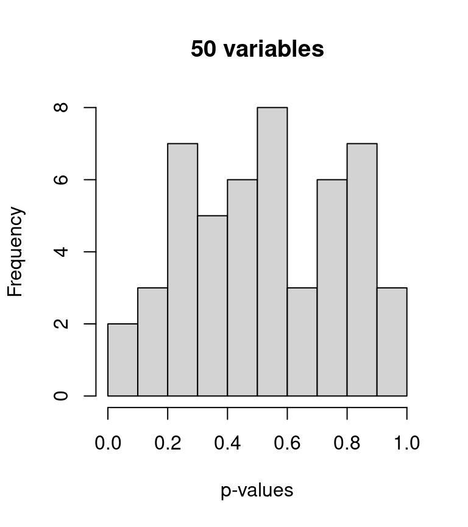

```r
hist(summary(r.lm.aic)$coef[-1, 4], freq = T, main = "50 variables",
    xlab = "p-values")
```

3. Then use AICc minimization to obtain the objectively “best” model:

```r
library(MASS)
r.AICmin <- stepAIC(r.lm.aic, direction = c("both"), trace = FALSE, AICc = TRUE)
```

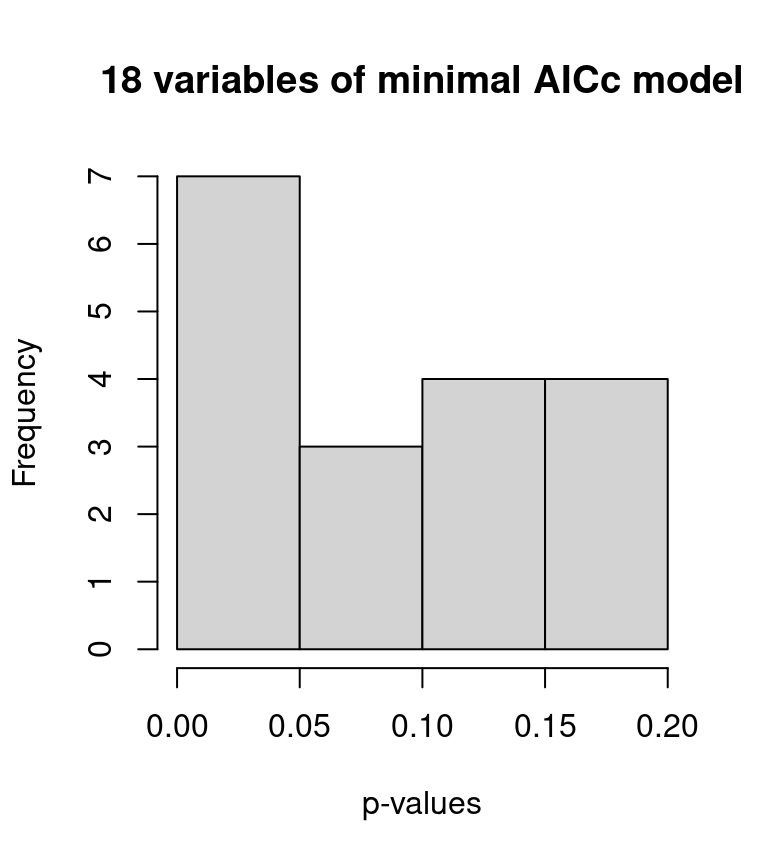

```r
hist(summary(r.AICmin)$coef[-1, 4], freq = T, main = "18 variables of minimal AICc model",
    xlab = "p-values")
```

The distribution of the $p$-values is now skewed: many of them reach rather small values (7 have $p<0.05$). This happened *although none of the variables has any explanatory power!*

## Summary: Main problem with model selection

$~$

$~$

$~$

**Exception**: Shrinkage methods!

Which methods are suitable for explanation (inference)?

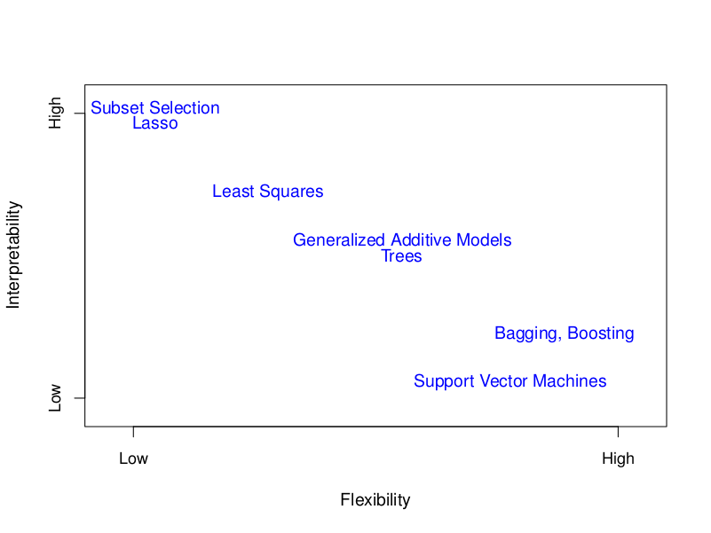

### Bottomline

$~$

- *Less flexible* models tend to have *better interpretability* and are therefore better suited *for explanation* than more flexible models.
- The *more flexible* a model, the better it tends to perform *for prediction*.
- Some models can be used for both, prediction and explanation, but then the approach how to build the model (e.g., how to select variables) should still depend on the aim.

$~$

Thank you for attending this course - good luck for the exam!

# References

Clayton, D., and M. Hills. 1993. *Statistical Models in Epidemiology*. Oxford: Oxford University Press.

Copas, J. B. 1983. “Regression, Prediction and Shrinkage.” *Journal of the Royal Statistical Society. Series B (Statistical Methodology)* 45: 311–54.

Freedman, D. A. 1983. “A Note on Screening Regression Equations.” *The American Statistician* 37: 152–55.

James, Gareth, Daniela Witten, Trevor Hastie, and Robert Tibshirani. 2013. *An Introduction to Statistical Learning*. Vol. 112. Springer.

James, G., D. Witten, T. Hastie, and R. Tibshirani. 2021. *An Introduction to Statistical Learning with Applications in r*. 2nd ed. New York: Springer.